# Part II - Prosper Loan Data

## by Ayomide Adenuga

> In this investigation, I would like to look into the features of loans that could affect or predict a borrower's Rate. I am looking to see how certain variables might affect the Rate relationship with another variable.

## Investigation Overview

> In this investigation, I would like to look into the features of loans that could affect or predict a borrower's Rate. I am looking to see how certain variables might affect the Rate relationship with another variable.

## Dataset Overview

> This dataset contains 113,937 loans with 81 variables on each loans,.

## (Visualization 1)

> We can infer from the chart that the Borrower's are predominantly living up to their responsibility.

> People still repaying their loan are the highest follwed by those that have completed paying

> Most of the loans are marked as 'current', followed by 'Completed' and 'Charged off'. This means that most people pay back their loan.

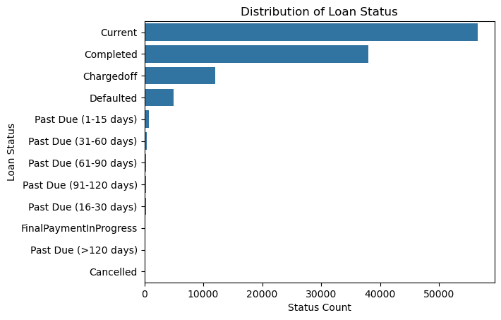

## (Visualization 2)

> The relationship between the 'BorrowerRate' and the 'BorrowerAPR' has and upward trend this means the higher the Borrower rate the higher the Borrower APR and vice versa.

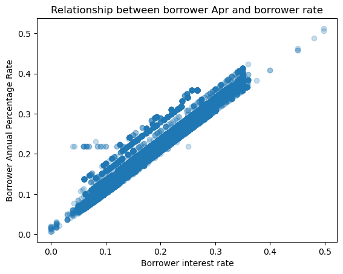

## (Visualization 3)

> Loans with terms of 12 months has the lowest interest.

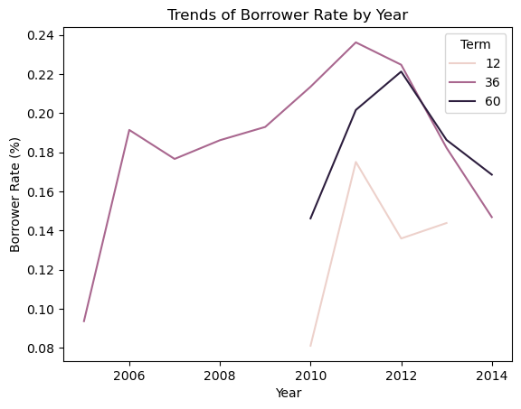